# Clase k-nn

Mejorado por EFVO

5 de julio de 2019

## Introducción

Los datos fueron descargados del [sitio web del texto guía](http://www-bcf.usc.edu/~gareth/ISL/). Se cargan así con el siguiente código:

```r
datos_advertising<-read.csv("Advertising.csv")
datos_advertising<-datos_advertising[,-1] # Se elimina la primera columna de índices
```

```r
head(datos_advertising)
```

```
##      TV radio newspaper sales
## 1 230.1  37.8      69.2  22.1
## 2  44.5  39.3      45.1  10.4
## 3  17.2  45.9      69.3   9.3
## 4 151.5  41.3      58.5  18.5
## 5 180.8  10.8      58.4  12.9
## 6   8.7  48.9      75.0   7.2
```

La función **pairs()** muestra los gráficos de dispersión por pares:

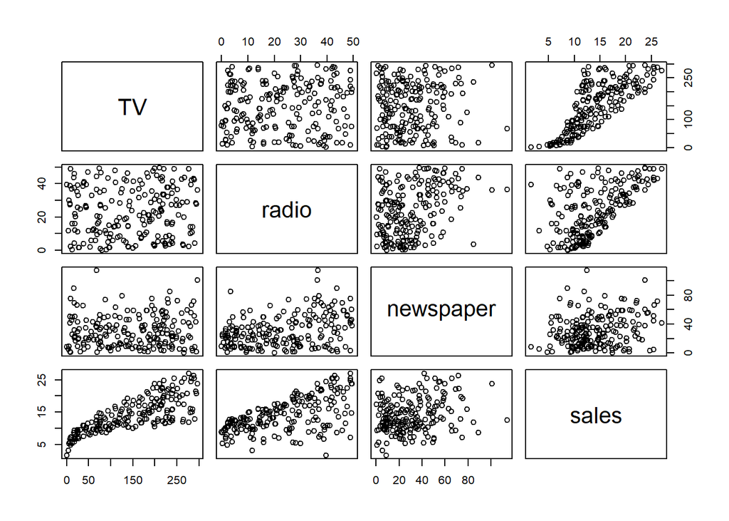

```r
pairs(datos_advertising)
```

Este ejemplo en particular tiene un elemento que facilita el análisis: las variables explicativas están todas en las mismas unidades.

con la función str se pueden tener datos sobre el numero de observaciones y el tipo de datos

```r
str(datos_advertising)
```

```
## 'data.frame':    200 obs. of  4 variables:
##  $ TV       : num  230.1 44.5 17.2 151.5 180.8 ...
##  $ radio    : num  37.8 39.3 45.9 41.3 10.8 48.9 32.8 19.6 2.1 2.6 ...
##  $ newspaper: num  69.2 45.1 69.3 58.5 58.4 75 23.5 11.6 1 21.2 ...
##  $ sales    : num  22.1 10.4 9.3 18.5 12.9 7.2 11.8 13.2 4.8 10.6 ...
```

Se puede usar la libreria skimr para tener una mayor descripción de las variables

```r
library(skimr)
skimr::skim(datos_advertising)
```

```
## Skim summary statistics
##  n obs: 200
##  n variables: 4
##
## -- Variable type:numeric ---------------------------------------------------------------------------------------
##   variable missing complete   n   mean    sd  p0   p25    p50    p75  p100
##  newspaper       0      200 200  30.55 21.78 0.3 12.75  25.75  45.1  114
##      radio       0      200 200  23.26 14.85 0    9.97  22.9   36.52  49.6
##      sales       0      200 200  14.02  5.22 1.6 10.38  12.9   17.4   27
##         TV       0      200 200 147.04 85.85 0.7 74.38 149.75 218.82 296.4
##      hist
##  ▇▇▅▅▂▁▁▁
##  ▇▆▅▅▆▅▆▅
##  ▁▃▇▇▆▃▃▂
##  ▆▅▆▅▅▇▆▅
```

```r
library(caret)
```

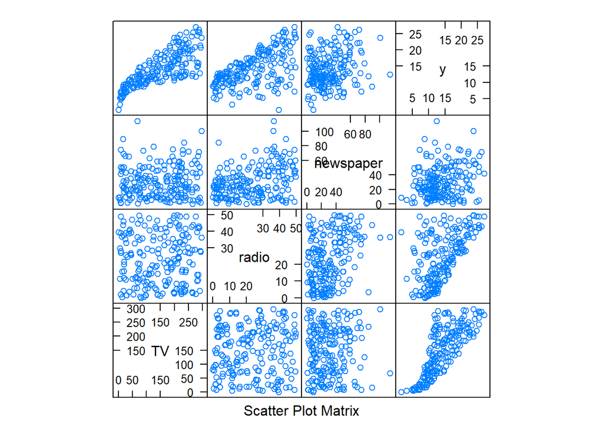

```r
featurePlot(x = datos_advertising[, 1:3],
            y = datos_advertising$sales,
            plot = "pairs",
            ## Add a key at the top
            auto.key = list(columns = 8))
```

```r
head(iris)
```

```
##   Sepal.Length Sepal.Width Petal.Length Petal.Width Species
## 1          5.1         3.5          1.4         0.2  setosa
## 2          4.9         3.0          1.4         0.2  setosa
## 3          4.7         3.2          1.3         0.2  setosa
## 4          4.6         3.1          1.5         0.2  setosa
## 5          5.0         3.6          1.4         0.2  setosa
## 6          5.4         3.9          1.7         0.4  setosa
```

Si hubiese alguna variable categorica se podría usar esta funcion de caret

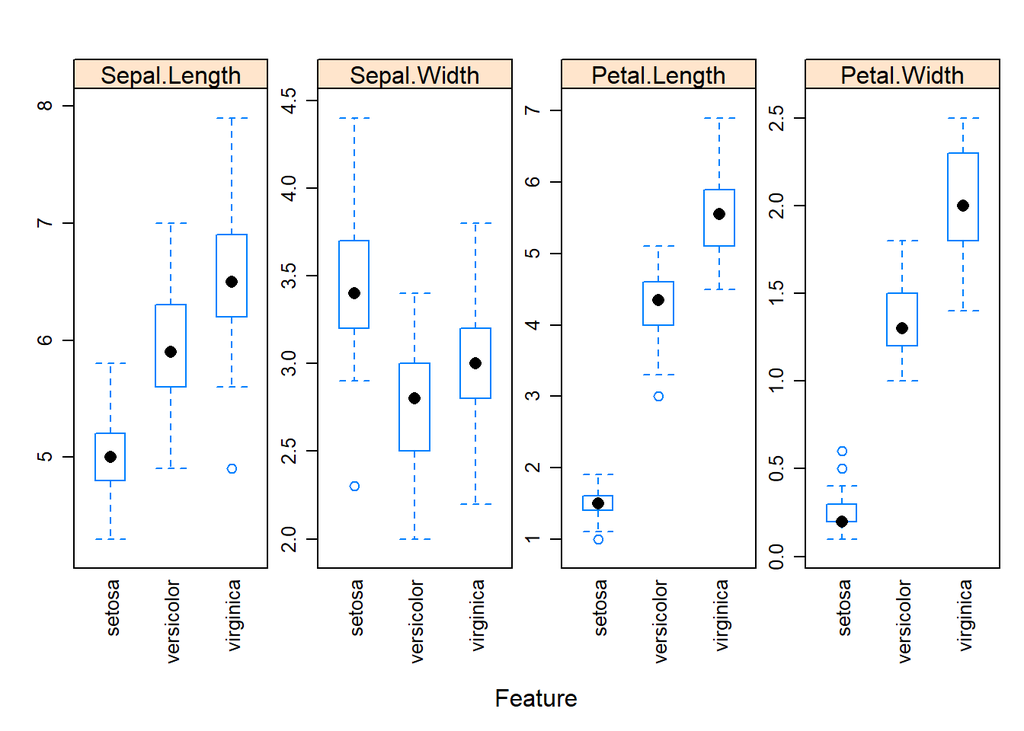

```r
featurePlot(x = iris[, 1:4],
            y = iris$Species,
            plot = "box",
            ## Pass in options to bwplot()
            scales = list(y = list(relation="free"),
                          x = list(rot = 90)),
            layout = c(4,1 ),
            auto.key = list(columns = 2))
```

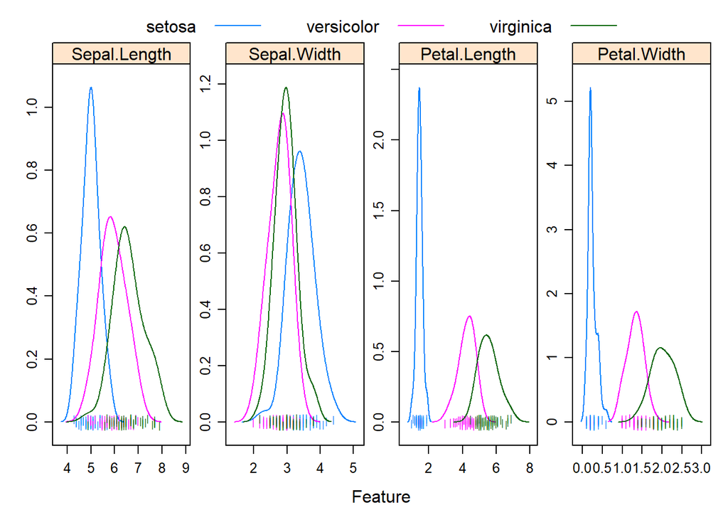

```r
featurePlot(x = iris[, 1:4],
            y = iris$Species,
            plot = "density",
            ## Pass in options to xyplot() to
            ## make it prettier
            scales = list(x = list(relation="free"),
                          y = list(relation="free")),
            adjust = 1.5,
            pch = "|",
            layout = c(4, 1),
            auto.key = list(columns = 3))
```

## Aplicación de la técnica de los vecinos más cercanos

Antes de aplicar la técnica de los vecinos más cercanos se particiona el conjunto de datos en entrenamiento y validación:

```r
set.seed(1) # fija la semilla del generador de números
            # aleatorios para obtener resultados reproducibles
p_tr<-0.7 #porcentaje de datos usados para el entrenamiento
N_datos<-dim(datos_advertising)[1] # número de registros del conjunto de datos
n_tr<-round(N_datos*p_tr) # este será el tamaño del conjunto de entrenamiento
ix_tr<-sample(N_datos,n_tr,replace = FALSE) # genera una muestra de índices
datos_tr<-datos_advertising[ix_tr,] # conjunto de entrenamiento
datos_vl<-datos_advertising[-ix_tr,] # conjunto de validación validación
```

El siguiente código implementa el método de los vecinos más cercanos del paquete **caret**. Luego utiliza la función **predict()** para predecir los datos de entrenamiento y calcula el MSE:

```r
library(caret) # contiene una implementación del método de los kNN
adv_knn<-knnreg(sales~TV+radio+newspaper,data=datos_tr,k=3) # evalúa el método con k=3
y_tr_pred<-predict(adv_knn,datos_tr)
mse_tr<-mean((datos_tr$sales-y_tr_pred)^2) # calcula el mse de entrenamiento
(mse_tr)
```

```
## [1] 1.2775
```

El siguiente código permite calcular el MSE en el conjunto de validación:

```r
y_vl_pred<-predict(adv_knn,datos_vl)
mse_vl<-mean((datos_vl$sales-y_vl_pred)^2)
(mse_vl)
```

```
## [1] 1.524037
```

## ¿Cuál es el número de vecinos óptimo?

Primero creamos una función que nos permita obtener el MSE como una función del número de vecinos:

```r
mse_k<-function(k,data_tr,data_vl,formula_mod){
  adv_knn<-knnreg(formula_mod,data=datos_tr,k=k) # entrenamiento del modelo
  y_tr_pred<-predict(adv_knn,datos_tr) # predicción de los valores de entrenamiento
  mse_tr<-mean((datos_tr$sales-y_tr_pred)^2) # mse del entrenamiento
  y_vl_pred<-predict(adv_knn,datos_vl) # predicción de los valores de prueba
  mse_vl<-mean((datos_vl$sales-y_vl_pred)^2) # mse de validación
  return(list(mse_tr=mse_tr,mse_vl=mse_vl))
  }
```

¿Cómo se utiliza esta función? El siguiente código muestra cómo hacerlo:

```r
modelo<-formula("sales~TV+radio+newspaper")
mse_k(k=2,data_tr=data_tr,data_vl = data_vl,formula_mod = modelo)
```

```
## $mse_tr
## [1] 0.9094643
##
## $mse_vl
## [1] 1.401417
```

Ahora, se aplica la función **mse_k()** a los valores de $k$ entre 1 y el número de datos en el conjunto de entrenamiento:

```r
MSE<-lapply(1:n_tr,mse_k,data_tr=data_tr,data_vl = data_vl,formula_mod = modelo)
```

El objeto MSE es una lista de listas: cada entrada de MSE es una lista con dos componentes. Para acceder a sus elementos de manera organizada pordemos utilizar la función **`[`** y la función **sapply()** como se muestra:

```r
mse_tr<-sapply(1:n_tr,function(x,y){`[[`(y,x)$mse_tr},y=MSE)
mse_vl<-sapply(1:n_tr,function(x,y){`[[`(y,x)$mse_vl},y=MSE)
```

Ahora ya pueden graficarse los MSE de entrenamiento y validación en función del número de vecinos:

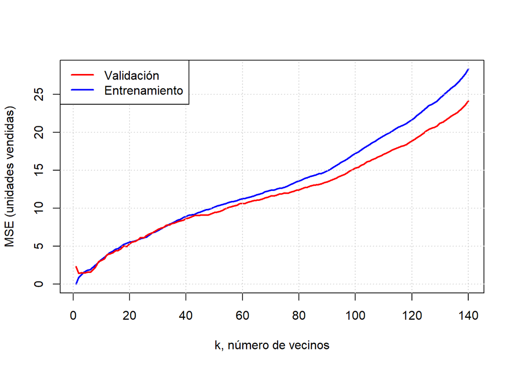

```r
num_vec<-1:n_tr
plot(num_vec,mse_tr,type="l",col="blue",lwd=2,xlab="k, número de vecinos",
     ylab="MSE (unidades vendidas)")
lines(num_vec,mse_vl,col="red",lwd=2)
grid()
legend("topleft",col=c("red","blue"),lwd=2,
       legend=c("Validación","Entrenamiento"))
```

Hagamos un zoom a lo que pasa cuando $k<10$:

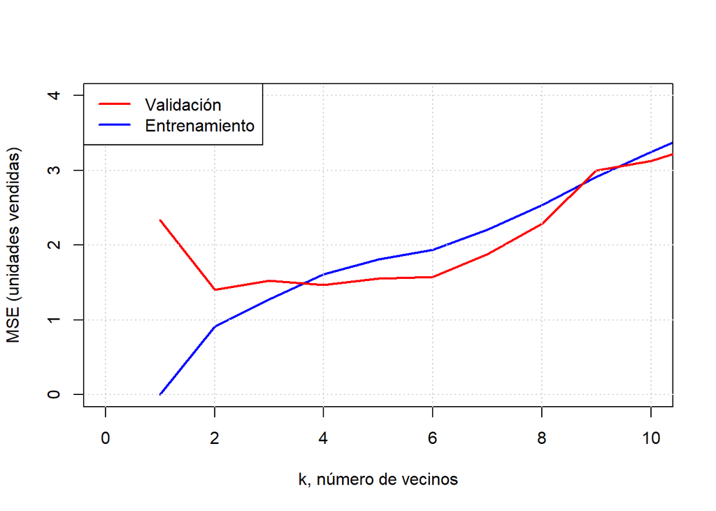

```r
num_vec<-1:n_tr
plot(num_vec,mse_tr,type="l",col="blue",lwd=2,xlab="k, número de vecinos",
     ylab="MSE (unidades vendidas)",xlim=c(0,10),ylim=c(0,4))
lines(num_vec,mse_vl,col="red",lwd=2)
grid()
legend("topleft",col=c("red","blue"),lwd=2,
       legend=c("Validación","Entrenamiento"))
```

## La libreria caret tambien tiene incorporado un algoritmo para el cálculo del k óptimo

```r
library(caret)
library(class)
set.seed(2018)
```

Se ejecuta con el metodo train de caret, el cual requiere los parametros trControl. En este caso se utiliza el method=cv indicando que se utilizará el Cross Validation, esto es, dividir los datos de entrenamiento en 10 partes y hacer 10 modelos cada uno excluyendo 1/10 parte de los datos. Con esto se logra mejorar la estimación del error utilizando el 100% de los datos. En la función train, se realiza el modelo con todas las variables usando los datos datos_tr. Aunque en este caso no se requiere, se realizó una estandarización de las variables con preProcess=c(“center”, “scale”).

```r
trcntrl = trainControl(method="cv", number=10)
caret_knn_fit = caret::train(sales~TV+radio+newspaper, data=datos_tr,
                      method = "knn", trControl = trcntrl,
                      preProcess=c("center", "scale"),
                      tuneLength = 10)
```

A continuación se observa que se selecciona K=5 pues minimiza el MSE y RMSE.

```r
caret_knn_fit
```

```
## k-Nearest Neighbors
##
## 140 samples
##   3 predictor
##
## Pre-processing: centered (3), scaled (3)
## Resampling: Cross-Validated (10 fold)
## Summary of sample sizes: 125, 126, 126, 127, 126, 127, ...
## Resampling results across tuning parameters:
##
##   k   RMSE      Rsquared   MAE
##    5  1.484750  0.9376783  1.083185
##    7  1.546725  0.9336793  1.085150
##    9  1.594466  0.9306034  1.127213
##   11  1.666725  0.9228758  1.170017
##   13  1.709251  0.9209409  1.193148
##   15  1.784332  0.9143169  1.252817
##   17  1.844285  0.9099095  1.297509
##   19  1.855108  0.9141794  1.308362
##   21  1.897751  0.9088949  1.368434
##   23  1.929708  0.9078643  1.388000
##
## RMSE was used to select the optimal model using the smallest value.
## The final value used for the model was k = 5.
```

Se repite la estimación con el method=“repeatedcv” para ver si cambia la decisión de K, pero continua siendo K=5

```r
trcntrl = trainControl(method="repeatedcv", number=10, repeats=4)
caret_knn_fit = caret::train(sales~TV+radio+newspaper, data=datos_tr,
                      method = "knn", trControl = trcntrl,
                      preProcess=c("center", "scale"),
                      tuneLength = 50)
caret_knn_fit
```

```
## k-Nearest Neighbors
##
## 140 samples
##   3 predictor
##
## Pre-processing: centered (3), scaled (3)
## Resampling: Cross-Validated (10 fold, repeated 4 times)
## Summary of sample sizes: 127, 127, 126, 125, 127, 126, ...
## Resampling results across tuning parameters:
##
##   k    RMSE      Rsquared   MAE
##     5  1.452033  0.9363073  1.058442
##     7  1.533454  0.9334990  1.081815
##     9  1.601863  0.9294299  1.128829
##    11  1.644703  0.9272929  1.158779
```

[output cut: 49 more lines]

Se realiza con predición con los mismos datos de datos_tr para calcular el MSE

```r
y_tr_pred<-predict(caret_knn_fit,datos_tr)
mse_tr<-mean((datos_tr$sales-y_tr_pred)^2) # calcula el mse de entrenamiento
RMSE_tr = sqrt(mse_tr)
mse_tr
```

```
## [1] 1.41896
```

```r
RMSE_tr
```

```
## [1] 1.191201
```

Ahora el cálculo del MSE y RMSE con los datos de validación, que en este caso se entiende que son de test pues la validación se hizo con cross validation

```r
y_vl_pred<-predict(caret_knn_fit,datos_vl)
mse_vl<-mean((datos_vl$sales - y_vl_pred)^2)
RMSE_tr = sqrt(mse_vl)
mse_vl
```

```
## [1] 1.631127
```

```r
RMSE_tr
```

```
## [1] 1.277156
```